# cox_forest() Tutorial

Julian Silan

2026-08-19

This tutorial walks through `cox_forest()` end to end using `survival::lung`, a built-in dataset of advanced lung cancer patients. It covers data preparation, a basic univariable forest plot, categorical vs. continuous covariates, custom reference levels, level exclusion, multivariable models, multiple endpoints, and the main styling arguments.

Source the function first (adjust the path to wherever `cox_forest.R` lives relative to this `.Rmd` file):

```r
source("/Users/julian/Desktop/VHIO/R code/Forestplot/Univariable_Multivariable/cox.forest_function.R")
```

```r
library(survival)
library(dplyr)
```

# 1 Prepare the data

`survival::lung` needs a little massaging before it’s ready for Cox modelling: `status` is coded 1/2 (censored/dead) rather than 0/1, `sex` is an unlabelled numeric code, and `ph.ecog` is stored as numeric even though it is really an ordered categorical performance-status score. We also add a synthetic treatment arm and a synthetic PFS endpoint so the tutorial can demonstrate multivariable models and multi-endpoint plots.

```r
set.seed(42)

lung2 <- survival::lung %>%
  mutate(
    event_os  = status - 1,                       # 1 = death, 0 = censored
    time_os   = time,
    sex       = factor(sex, levels = c(1, 2), labels = c("Male", "Female")),
    ph.ecog   = factor(ph.ecog),                   # 0-3 performance status
    treatment = sample(c("Arm A", "Arm B"), n(), replace = TRUE),
    time_pfs  = pmin(time_os, time_os * runif(n(), 0.4, 0.9)),
    event_pfs = ifelse(time_pfs < time_os, 1, event_os)
  ) %>%
  filter(!is.na(ph.ecog), !is.na(sex), !is.na(age))

#glimpse(lung2)
```

> `time_pfs` / `event_pfs` here are a *simulated* PFS endpoint (PFS event always occurs no later than OS) purely so the tutorial has two endpoints to work with — `survival::lung` does not contain real PFS data.

# 2 A single-covariate univariable forest plot

The simplest possible call: one categorical covariate, one endpoint, univariable model.

```r
res_sex <- cox_forest(
  data       = lung2,
  covariates = "sex",
  labels     = "Sex",
  time       = "time_os",
  event      = "event_os",
  endpoint_labels = "OS",
  model_type = "univariable"
)

res_sex$results_table
```

| covariate | covariate_label | level | is_reference | n | n_event | hr | conf_low | conf_high | p_value | endpoint | endpoint_label | model_type |
| --- | --- | --- | --- | --- | --- | --- | --- | --- | --- | --- | --- | --- |
| sex | Sex | Male | TRUE | 137 | 111 | NA | NA | NA | NA | time_os | OS | univariable |
| sex | Sex | Female | FALSE | 90 | 53 | 0.5923301 | 0.4266362 | 0.8223749 | 0.0017597 | time_os | OS | univariable |

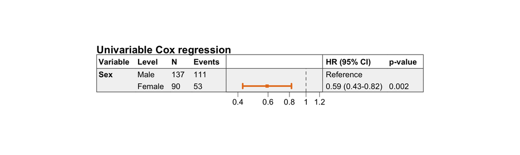

```r
res_sex$plots$univariable
```

`results_table` has one row per covariate level — including an explicit `"Reference"` row for the first factor level (`"Male"`, since that’s `levels(lung2$sex)[1]`) with `hr`/`conf_low`/`conf_high` set to `NA`. The plot draws no marker or CI line for that row, exactly as expected for a reference category.

# 3 Several covariates at once (categorical + continuous)

Add `age` (continuous — auto-detected because it has more than 5 distinct values) and `ph.ecog` (categorical, 4 levels). Each covariate still gets its **own** univariable Cox model: `Surv(time_os, event_os) ~ age`, `Surv(time_os, event_os) ~ sex`, `Surv(time_os, event_os) ~ ph.ecog`.

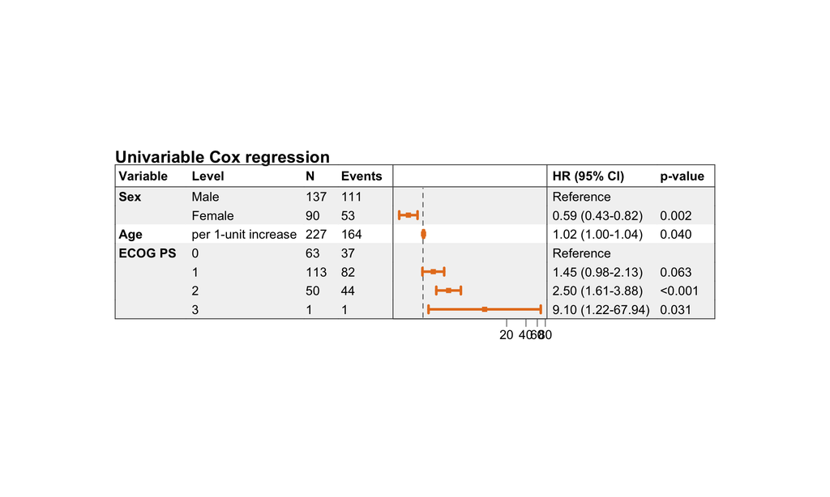

```r
res_uni <- cox_forest(
  data       = lung2,
  covariates = c("sex", "age", "ph.ecog"),
  labels     = c("Sex", "Age", "ECOG PS"),
  time       = "time_os",
  event      = "event_os",
  endpoint_labels = "OS",
  continuous_vars = "age",
  model_type = "univariable"
)

res_uni$plots$univariable
```

## 3.1 Specify x-axis

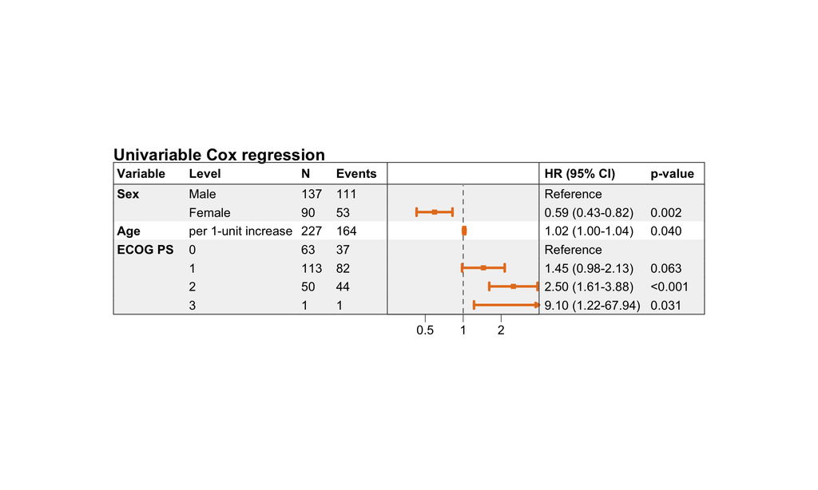

```r
res_uni <- cox_forest(
  data       = lung2,
  covariates = c("sex", "age", "ph.ecog"),
  labels     = c("Sex", "Age", "ECOG PS"),
  time       = "time_os",
  event      = "event_os",
  endpoint_labels = "OS",
  continuous_vars = "age",
  model_type = "univariable",
  xlim = c(0.25, 4),
  ticks_at = c(0.5, 1, 2),
)

res_uni$plots$univariable
```

For `age`, `results_table$level` reads `"per 1-unit increase"`. To report the HR per 10-year increase instead:

```r
res_uni_age10 <- cox_forest(
  data       = lung2,
  covariates = c("sex", "age", "ph.ecog"),
  labels     = c("Sex", "Age", "ECOG PS"),
  time       = "time_os",
  event      = "event_os",
  continuous_vars = "age",
  continuous_increase = list(age = 10),
  model_type = "univariable"
)

res_uni_age10$results_table %>% filter(covariate == "age")
```

| covariate | covariate_label | level | is_reference | n | n_event | hr | conf_low | conf_high | p_value | endpoint | endpoint_label | model_type |
| --- | --- | --- | --- | --- | --- | --- | --- | --- | --- | --- | --- | --- |
| age | Age | per 10-unit increase | FALSE | 227 | 164 | 1.208873 | 1.008797 | 1.448629 | 0.0398942 | time_os | time_os | univariable |

# 4 Custom reference levels

By default the reference level for a categorical covariate is its first factor level. Use `ref_levels` to change that — useful, for example, to make `"Female"` the reference for `sex`, or a “good” ECOG score the reference instead of `"0"`.

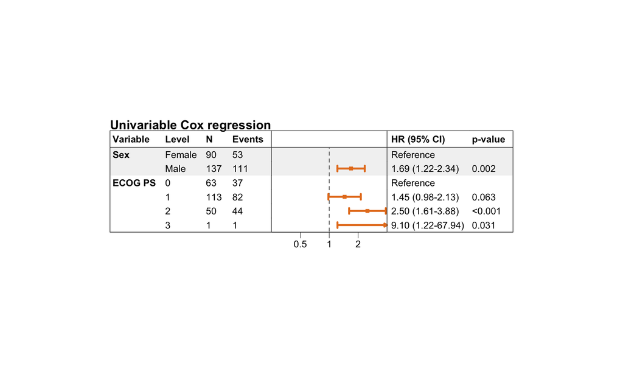

```r
res_ref <- cox_forest(
  data       = lung2,
  covariates = c("sex", "ph.ecog"),
  labels     = c("Sex", "ECOG PS"),
  time       = "time_os",
  event      = "event_os",
  ref_levels = list(sex = "Female"),
  model_type = "univariable",
  xlim = c(0.25, 4),
  ticks_at = c(0.5, 1, 2),
)

res_ref$plots$univariable
```

# 5 Excluding a level

`ph.ecog == "3"` has only a handful of patients in `lung`. `exclude_levels` drops it by setting those values to `NA`, which then falls out through the existing complete-case filtering used inside each model:

```r
res_excl <- cox_forest(
  data       = lung2,
  covariates = c("sex", "ph.ecog"),
  labels     = c("Sex", "ECOG PS"),
  time       = "time_os",
  event      = "event_os",
  exclude_levels = list(ph.ecog = "3"),
  model_type = "univariable"
)

res_excl$results_table %>% filter(covariate == "ph.ecog")
```

| covariate | covariate_label | level | is_reference | n | n_event | hr | conf_low | conf_high | p_value | endpoint | endpoint_label | model_type |
| --- | --- | --- | --- | --- | --- | --- | --- | --- | --- | --- | --- | --- |
| ph.ecog | ECOG PS | 0 | TRUE | 63 | 37 | NA | NA | NA | NA | time_os | time_os | univariable |
| ph.ecog | ECOG PS | 1 | FALSE | 113 | 82 | 1.445768 | 0.9794896 | 2.134014 | 0.0635040 | time_os | time_os | univariable |
| ph.ecog | ECOG PS | 2 | FALSE | 50 | 44 | 2.497529 | 1.6082942 | 3.878427 | 0.0000458 | time_os | time_os | univariable |

For a **multivariable** model this exclusion drops the affected patients from the entire model (since multivariable fitting requires complete cases across every covariate simultaneously) — see the next section.

# 6 Multivariable models

Setting `model_type = "multivariable"` fits **one** Cox model containing all requested covariates together: `Surv(time_os, event_os) ~ sex + age + ph.ecog`.

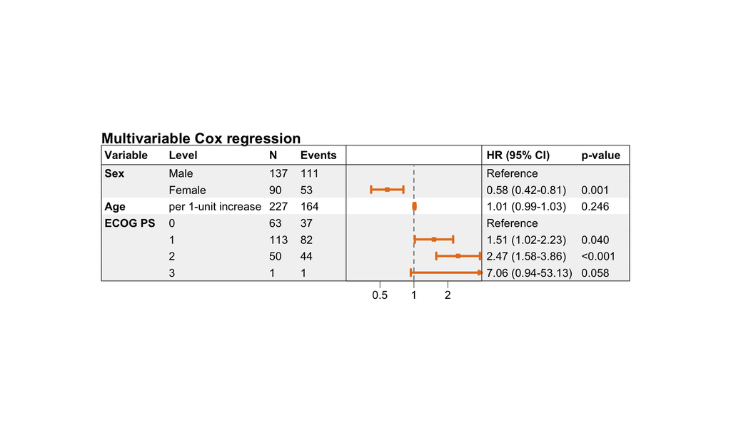

```r
res_multi <- cox_forest(
  data       = lung2,
  covariates = c("sex", "age", "ph.ecog"),
  labels     = c("Sex", "Age", "ECOG PS"),
  time       = "time_os",
  event      = "event_os",
  continuous_vars = "age",
  model_type = "multivariable",
  xlim = c(0.25, 4),
  ticks_at = c(0.5, 1, 2),
)

res_multi$plots$multivariable
```

To see univariable and multivariable side by side (e.g. for a “crude vs adjusted” supplementary table), request both:

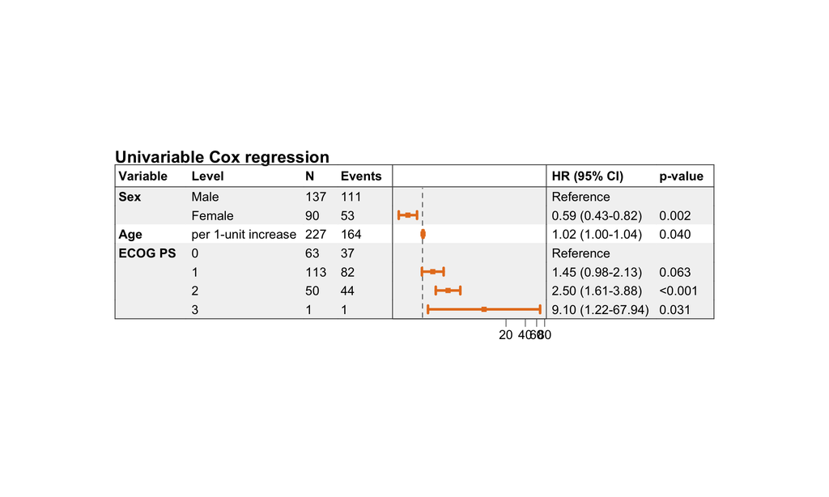

```r
res_both <- cox_forest(
  data       = lung2,
  covariates = c("sex", "age", "ph.ecog"),
  labels     = c("Sex", "Age", "ECOG PS"),
  time       = "time_os",
  event      = "event_os",
  continuous_vars = "age",
  model_type = "both"
)

res_both$plots$univariable
```

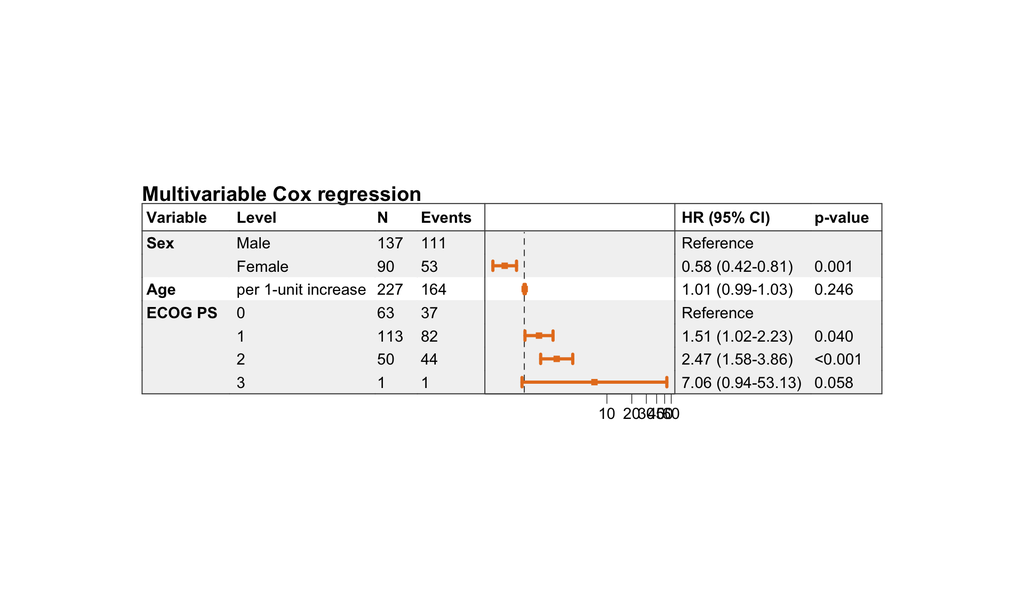

```r
res_both$plots$multivariable
```

# 7 Including a treatment / arm variable

There’s nothing special about a treatment arm — add it to `covariates` (and `labels`) exactly like any other covariate:

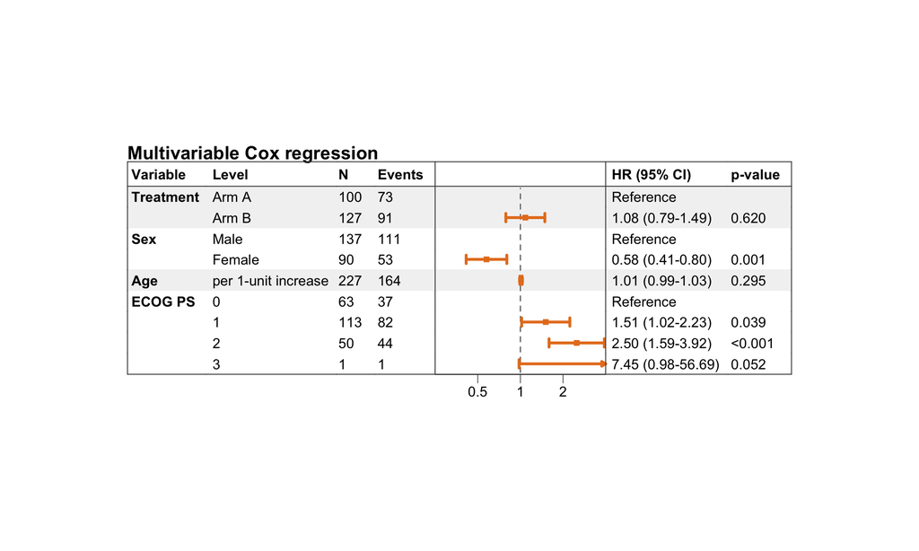

```r
res_trt <- cox_forest(
  data       = lung2,
  covariates = c("treatment", "sex", "age", "ph.ecog"),
  labels     = c("Treatment", "Sex", "Age", "ECOG PS"),
  time       = "time_os",
  event      = "event_os",
  continuous_vars = "age",
  ref_levels = list(treatment = "Arm A"),
  model_type = "multivariable",
  xlim = c(0.25, 4),
  ticks_at = c(0.5, 1, 2),
)

res_trt$plots$multivariable
```

# 8 Multiple endpoints (OS and PFS) with colour coding

Pass `time` and `event` as vectors, paired by position, along with matching `endpoint_labels`. With more than one endpoint the plot automatically colour-codes the confidence intervals per endpoint and adds a legend below the figure.

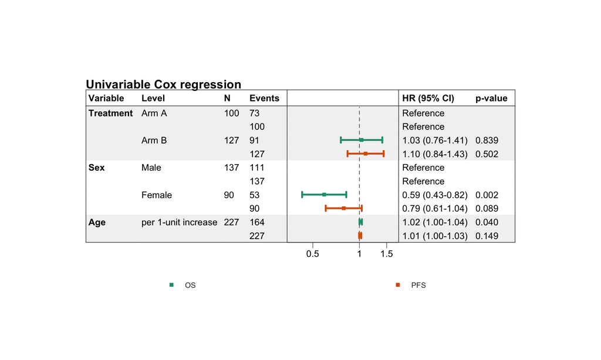

```r
res_two_ep <- cox_forest(
  data       = lung2,
  covariates = c("treatment", "sex", "age"),
  labels     = c("Treatment", "Sex", "Age"),
  time       = c("time_os", "time_pfs"),
  event      = c("event_os", "event_pfs"),
  endpoint_labels = c("OS", "PFS"),
  continuous_vars = "age",
  ref_levels = list(treatment = "Arm A"),
  model_type = "univariable",
  palette    = c("#1B9E77", "#D95F02")   # one colour per endpoint
)

res_two_ep$plots$univariable
```

Rows are grouped covariate-major (all OS/PFS rows for `Treatment` together, then all rows for `Sex`, then `Age`), so each covariate’s cross-endpoint comparison stays visually adjacent.

# 9 Styling the plot

A few of the most commonly adjusted arguments:

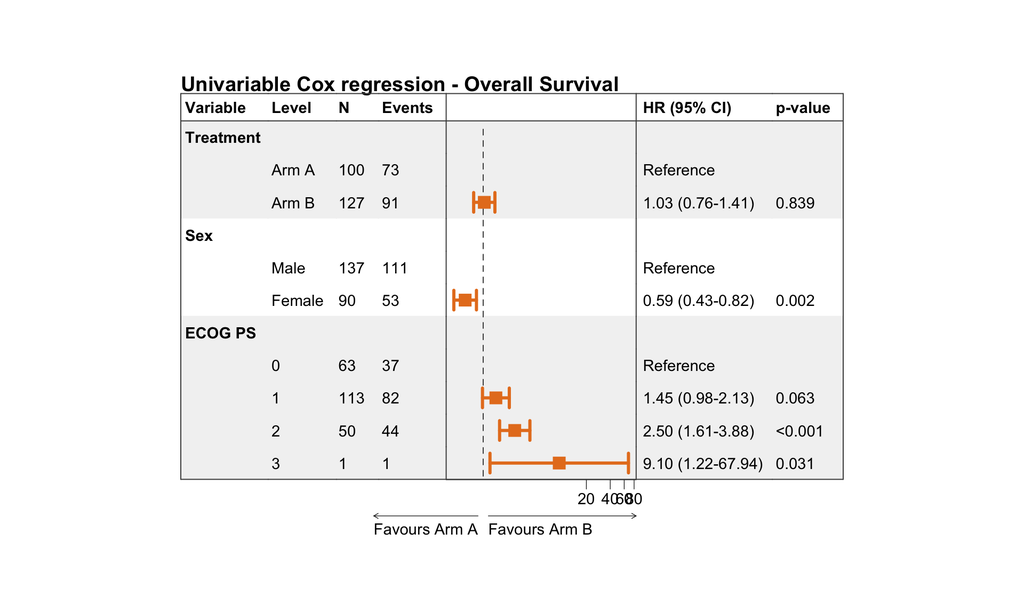

```r
res_styled <- cox_forest(
  data       = lung2,
  covariates = c("treatment", "sex", "ph.ecog"),
  labels     = c("Treatment", "Sex", "ECOG PS"),
  time       = "time_os",
  event      = "event_os",
  ref_levels = list(treatment = "Arm A"),
  model_type = "univariable",
  digits      = 2,
  row_height  = 1.4,                    # 40% taller rows
  ci_pch      = 15,                     # rectangle markers
  ci_lwd      = 3,                      # thickness of the lines
  ci_Theight = 0.6,                     # height of CI bands
  sizes       = 1,                      # size of HR
  risk_labels = c("Favours Arm A", "Favours Arm B"),
  title       = "Univariable Cox regression - Overall Survival",
  covariate_label_row = TRUE            # bold header row per covariate
)

res_styled$plots$univariable
```

- `row_height` — multiplier applied to every body row’s height (`1.3` = 30% taller); useful when labels wrap or the figure feels cramped.
- `covariate_label_row = TRUE` inserts a dedicated bold row with just the covariate name above its levels, instead of bolding the first level row in place.
- `risk_labels` adds directional arrow annotations under the x-axis (only makes sense when every covariate shares a consistent “favours A / favours B” framing, e.g. a single treatment-arm-anchored subgroup plot).
- `xlim` / `ticks_at` let you fix the axis range and tick marks manually instead of relying on the automatic (CI-range-based) defaults — handy for keeping several related figures on the same scale.

# 10 Adopt length of the forestplot

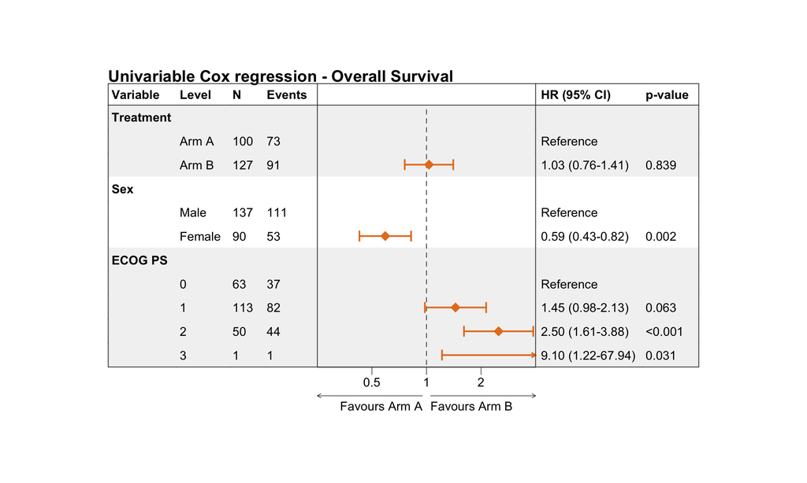

```r
res_length <- cox_forest(
  data       = lung2,
  covariates = c("treatment", "sex", "ph.ecog"),
  labels     = c("Treatment", "Sex", "ECOG PS"),
  time       = "time_os",
  event      = "event_os",
  ref_levels = list(treatment = "Arm A"),
  model_type = "univariable",
  xlim       = c(0.25, 4),
  ticks_at   = c( 0.5, 1, 2),
  digits      = 2,
  row_height  = 1.3,                    # 30% taller rows
  ci_pch      = 18,                     # diamond markers
  ci_lwd      = 2,
  sizes       = 1,                      # size of HR
  length_plot = 60,
  risk_labels = c("Favours Arm A", "Favours Arm B"),
  title       = "Univariable Cox regression - Overall Survival",
  covariate_label_row = TRUE            # bold header row per covariate
)

res_length$plots$univariable
```

# 12 Next steps

- See `README.md` for the full argument reference.
- See `test-cox_forest.R` for further worked examples of every argument, including edge cases like invalid reference levels and multi-endpoint level exclusion.